# Example of a Pipeline Combining BGData and BGLR

## Assumptions

Load the packages `BGData`, `BGLR`, `data.table`, and `qqman`:

```r
library(BGData)
library(BGLR)
library(data.table)
library(qqman)
```

Set paths:

- `genoPath` is the directory containing the .bed+.bim+.fam filesets (following the naming scheme `chrom{1..22,X,Y,XY,MT}`)
- `phenoPath` is the directory containing a preprepared phenotype file called `phenotypes.csv` with two initial columns `FID` and `IID`
- `sampleQcPath` is the directory containing the Sample-QC file (version 1)
- `withdrawalsPath` is the directory containing the project-specific list of samples that have withdrawn from UKB

## Module 1: Data Preparation

### 1. Form a linked array with genotypes

Load each chromosome as a BEDMatrix object and link them by columns to a ColumnLinkedMatrix object:

```r
X <- as.ColumnLinkedMatrix(lapply(c(1:22, "X", "Y", "XY", "MT"), function(chrom) {
    BEDMatrix(paste0(genoPath, "/chrom", chrom))
}))
rownames(X) <- sapply(strsplit(rownames(X), "_"), `[`, 1) # convert names from FID_IID to eid
```

Combine genotypes and phenotypes into a BGData object:

```r
DATA <- as.BGData(X, alternatePhenotypeFile = paste0(phenoPath, "/phenotypes.csv"))
```

## Module 2: Genotype Filtering

```r
allSamples <- rownames(DATA@geno)
allVariants <- colnames(DATA@geno)
```

The original 26 .bed files (autosomal chromosomes, sex chromosomes, and mitochondrial DNA) contain 805426 variants for each of the 488377 samples.

### 2. Determine white British cohort

Determine white samples using the `in.white.British.ancestry.subset` column of the sample QC file:

```r
sampleQC <- fread(paste0(sampleQcPath, "/ukb_sqc_v2.txt"), select = 24, col.names = "in.white.British.ancestry.subset", data.table = FALSE)
whiteSamples <- allSamples[sampleQC$in.white.British.ancestry.subset == "1"]
```

Load withdrawals and remove them from white British cohort:

```r
withdrawals <- scan(paste0(withdrawalsPath, "/w15326.csv"), what = "")
whiteSamples <- setdiff(whiteSamples, withdrawals)
```

There are 409637 white Caucasian samples.

### 3. Summaries

Compute summary statistics for each variant among all white British samples:

```r
summaries <- summarize(DATA@geno, i = whiteSamples, j = allVariants, chunkSize = 2500, nCores = 4)
```

### 4. SNP filtering

Remove variants with a minor allele frequency of <1% and a missing call rate of >5%:

```r
maf <- ifelse(summaries$allele_freq > 0.5, 1 - summaries$allele_freq, summaries$allele_freq)
qcedVariants <- allVariants[maf >= 0.01 & summaries$freq_na <= 0.05]
```

There are 624523 variants after filtering.

## Module 3: Removal of Related Samples

### 5. Genomic relationships (GR)

Compute a genomic relationship matrix among all white British samples:

```r
G <- getG_symDMatrix(DATA@geno, i = whiteSamples, j = qcedVariants, blockSize = 20000, chunkSize = 2500, nCores = 4)
```

```r
relatedWhiteSamples <- findRelated(G, 0.03)
unrelatedWhiteSamples <- setdiff(whiteSamples, relatedWhiteSamples)
```

There are 233117 unrelated samples among all white British samples.

## Module 4: Phenotype Adjustment

### 7. Computation of 5 PCs

Compute 5 PCs based on a singular-value decomposition and 5000 evenly spaced variants:

```r
evenlySpacedVariants <- round(seq(from = 100, to = ncol(DATA@geno) - 100, length.out = 5000))

svdX <- DATA@geno[unrelatedWhiteSamples, evenlySpacedVariants]
svdX[is.na(svdX)] <- 0 # impute missing values
svdX <- svdX[, apply(svdX, 2, sd) > 0] # remove constant columns
svdX <- scale(svdX)

SVD <- svd(svdX, nu = 5, nv = 0)

PCs <- data.frame(IID = unrelatedWhiteSamples, pc1 = SVD$u[, 1], pc2 = SVD$u[, 2], pc3 = SVD$u[, 3], pc4 = SVD$u[, 4], pc5 = SVD$u[, 5], stringsAsFactors = FALSE)
```

Merge the PCs into `DATA@pheno`:

```r
DATA@pheno <- orderedMerge(DATA@pheno, PCs, by = "IID")
```

### 8. Phenotype adjustments

Remove outliers for height:

```r
DATA@pheno$height[DATA@pheno$height < 147 & DATA@pheno$height > 210] <- NA
```

Adjust for sex, age, batch (named `PHENOTYPE` in the .fam file), center, and the 5 PCs:

```r
adjModel <- lm(height ~ factor(SEX) + age + factor(PHENOTYPE) + factor(center) + pc1 + pc2 + pc3 + pc4 + pc5, data = DATA@pheno, subset = unrelatedWhiteSamples, na.action = na.exclude)

adjustedPhenotypes <- data.frame(IID = unrelatedWhiteSamples, adjusted_height = residuals(adjModel), stringsAsFactors = FALSE)
```

Merge adjusted height into `DATA@pheno`:

```r
DATA@pheno <- orderedMerge(DATA@pheno, adjustedPhenotypes, by = "IID")
```

## Module 5: GWAS and Variant Selection

### 9. Building of training and test set

Remove samples with missing values:

```r
phenotypedUnrelatedWhiteSamples <- unrelatedWhiteSamples[!is.na(DATA@pheno[unrelatedWhiteSamples, "adjusted_height"])]
```

Build test set containing 10,000 samples and put the remaining samples into the training set:

```r
testSet <- sample(phenotypedUnrelatedWhiteSamples, size = 10000)
trainingSet <- setdiff(phenotypedUnrelatedWhiteSamples, testSet)
```

There are 222648 samples in the training set.

### 10. GWAS (using adjusted phenotypes)

Perform a genome-wide association study (GWAS) on the training set, regressing adjusted height on one variant at a time using `rayOLS` as regression method:

```r
GWAS <- GWAS(adjusted_height ~ 1, data = DATA, method = "rayOLS", i = trainingSet, j = qcedVariants, chunkSize = 2500, nCores = 4)
pValues <- GWAS[, 4]
```

Produce a Manhattan plot:

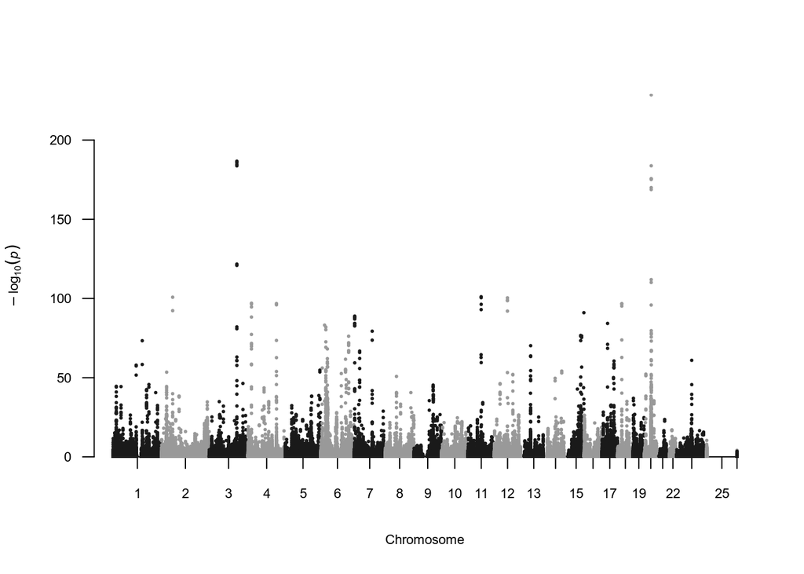

```r
manhattan <- data.frame(
    SNP = qcedVariants,
    CHR = DATA@map[qcedVariants, "chromosome"],
    P = pValues,
    BP = DATA@map[qcedVariants, "base_pair_position"],
    stringsAsFactors = FALSE
)
manhattan(manhattan, suggestiveline = FALSE, genomewideline = FALSE, cex = 0.4, cex.axis = 0.7, cex.lab = 0.7)
```

### 11. Selection of the top-p variants

```r
variantSet <- list(
    1:500,
    501:1000,
    1001:2000,
    2001:5000,
    5001:10000
)
```

```r
rankedVariants <- order(pValues)
```

## Module 6: Bayesian Regression and Assessment of Prediction Accuracy

### 12. Bayesian Genomic Regression

Fit a Bayesian regression model with the training set and an increasing number of variant groups per set using the BGLR package using the `BayesB` method:

```r
yTRN <- DATA@pheno[trainingSet, "adjusted_height"]

ETA <- vector(mode = "list", length = length(variantSet))
for (group in seq_along(variantSet)) {

    variantSelection <- qcedVariants[rankedVariants[variantSet[[group]]]]

    xTRN <- DATA@geno[trainingSet, variantSelection]

    sdTRN <- summaries[variantSelection, "sd"]
    muTRN <- summaries[variantSelection, "allele_freq"] * 2
    for (col in 1:ncol(xTRN)) {
        x <- xTRN[, col]
        x <- (x - muTRN[col]) / sdTRN[col]
        x[is.na(x)] <- 0
        xTRN[, col] <- x
    }

    ETA[[group]] <- list(X = xTRN, model = "BayesB")

}

# Fit model
fm <- BGLR(y = yTRN, ETA = ETA, nIter = 7000, burnIn = 2000)
```

### 13. Assessment of prediction accuracy

Predict height for samples in the test set using the estimated effects from the previous top-p set and SNP genotypes:

```r
yTST <- DATA@pheno[testSet, "adjusted_height"]

variantSelection <- qcedVariants[rankedVariants[unlist(variantSet)]]
xTST <- DATA@geno[testSet, variantSelection]

sdTST <- summaries[variantSelection, "sd"]
muTST <- summaries[variantSelection, "allele_freq"] * 2
for (col in 1:ncol(xTST)) {
    x <- xTST[, col]
    x <- (x - muTST[col]) / sdTST[col]
    x[is.na(x)] <- 0
    xTST[, col] <- x
}

bHat <- do.call("c", lapply(fm$ETA[seq_along(fm$ETA)], function(x) x$b))
yHatTST <- xTST %*% bHat + fm$mu
```

Correlate the predicted height with the sex-age adjusted height:

```r
cor(yTST, yHatTST)
```

```
##           [,1]
## [1,] 0.5273258
```

```r
cor(yTST, yHatTST)^2
```

```
##           [,1]
## [1,] 0.2780725
```